# PCA/Partial PCA for scRNA-seq Data

Ziqi Lei

- 1. Data Preparation
- 2. Exploratory Analysis
  - 2.1 Scree Plot Analysis
  - 2.2 Variance Summary Table
- 3. Determine Optimal k
- 4. Performance Benchmark
- 5. Accuracy Validation
- 6. Biological Interpretation
- 7. Data Quality Metrics
- 8. Discussion
- 9. Session Info

```r
set.seed(2025)
suppressPackageStartupMessages({
  library(ggplot2)
  library(dplyr)
  library(tidyr)
  library(knitr)
})
# Need：mixOmics / rARPACK / RSpectra / bench
have_bench <- requireNamespace("bench", quietly = TRUE)
have_mixOmics <- requireNamespace("mixOmics", quietly = TRUE)
```

# 1. Data Preparation

```r
data = readRDS(file = 'Data/HaffinaCovidPBMC_30000cells_dense.rds')
data = t(data)
cat("Original data dimensions:", nrow(data), "cells x", ncol(data), "genes\n")
```

```
## Original data dimensions: 30000 cells x 22642 genes
```

```r
# Subset the data to a specified size
ncell = 1500          # choose number of cells, do not go above 2000
ngene = 2000          # choose the number of genes, do not go above 5000

set.seed(2021)
index.cell = sample(rownames(data), replace = FALSE, size = ncell)
data2 = data[index.cell, 1:ngene]

# remove genes with 0 variance
gene.var = apply(data2, 2, var)
var.zero = which(gene.var == 0)
cat("Genes with zero variance:", length(var.zero), "\n")
```

```
## Genes with zero variance: 495
```

```r
# create the data ready to be analysed
data2 = data2[, setdiff(colnames(data2), names(var.zero))]
dim(data2) # data ready to be input in PCA
```

```
## [1] 1500 1505
```

```r
# Check data sparsity
zero_proportion <- sum(data2 == 0) / length(data2)
cat("Zero proportion:", round(zero_proportion * 100, 2), "%\n")
```

```
## Zero proportion: 91.5 %
```

```r
cat("Data class:", class(data2), "\n")
```

```
## Data class: matrix array
```

```r
cat("Data dimensions:", nrow(data2), "cells x", ncol(data2), "genes\n")
```

```
## Data dimensions: 1500 cells x 1505 genes
```

```r
cat("Non-zero proportion:", round((1 - zero_proportion) * 100, 2), "%\n")
```

```
## Non-zero proportion: 8.5 %
```

```r
# Summary statistics
cat("\nGene expression summary:\n")
```

```
##
## Gene expression summary:
```

```r
cat("  Mean expression:", round(mean(data2), 4), "\n")
```

```
##   Mean expression: 0.2308
```

```r
cat("  Median expression:", round(median(data2), 4), "\n")
```

```
##   Median expression: 0
```

```r
cat("  Max expression:", round(max(data2), 2), "\n")
```

```
##   Max expression: 695
```

```r
cat("  SD:", round(sd(data2), 4), "\n")
```

```
##   SD: 3.0522
```

# 2. Exploratory Analysis

Define methods for PCA:

```r
source("R/pca_pSVD.R")

run_pca_full <- function(X, k) {
  mixOmics::pca(X, ncomp = k, center = TRUE, scale = TRUE)
}

run_pca_psvd <- function(X, k) {
  pca_pSVD(X, ncomp = k, center = TRUE, scale = TRUE)
}
```

Both run_pca_full() and run_pca_psvd() use the same centering and scaling scheme for fair comparison.

pca_pSVD computes only the first k singular vectors using svds, theoretically equivalent to full SVD results (up to arbitrary sign flips).

## 2.1 Scree Plot Analysis

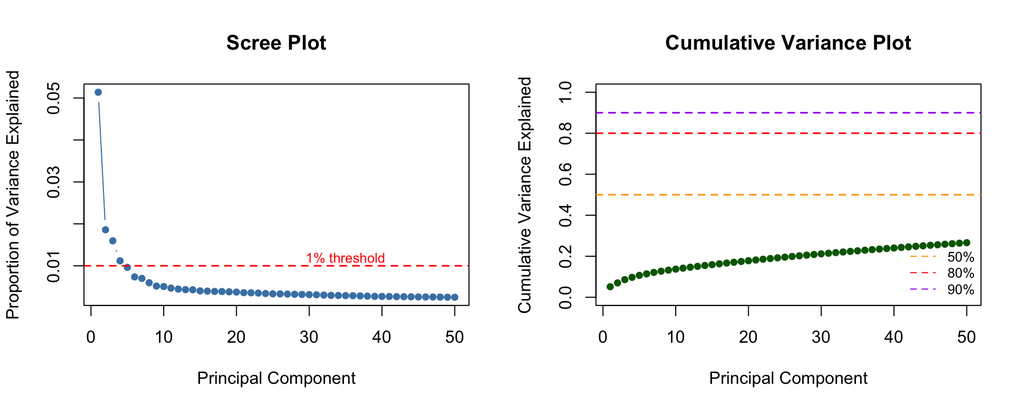

```r
# Run PCA with max components to explore variance
k_max = min(50, min(nrow(data2), ncol(data2)) - 1)
pca_explore = run_pca_full(data2, k = k_max)

var_explained = pca_explore$prop_expl_var$X
cumvar = cumsum(var_explained)

# Create scree plots
par(mfrow = c(1, 2))

# Individual variance explained
plot(var_explained, type = "b", pch = 19, col = "steelblue",
     xlab = "Principal Component",
     ylab = "Proportion of Variance Explained",
     main = "Scree Plot",
     cex = 0.8)
abline(h = 0.01, col = "red", lty = 2, lwd = 1.5)
text(k_max * 0.7, 0.012, "1% threshold", col = "red", cex = 0.8)

# Cumulative variance explained
plot(cumvar, type = "b", pch = 19, col = "darkgreen",
     xlab = "Principal Component",
     ylab = "Cumulative Variance Explained",
     main = "Cumulative Variance Plot",
     cex = 0.8, ylim = c(0, 1))
abline(h = c(0.5, 0.8, 0.9), col = c("orange", "red", "purple"),
       lty = 2, lwd = 1.5)
legend("bottomright",
       legend = c("50%", "80%", "90%"),
       col = c("orange", "red", "purple"),
       lty = 2, bty = "n", cex = 0.8)
```

```r
par(mfrow = c(1, 1))
```

The scree plot flattens quickly, with individual PCs contributing <1% variance beyond PC 10 — a hallmark of high-dimensional, sparse data.

This visualization helps identify an effective k range (≈ 10–30 PCs) for benchmarking.